# TMP Porewater ICP

## Counts

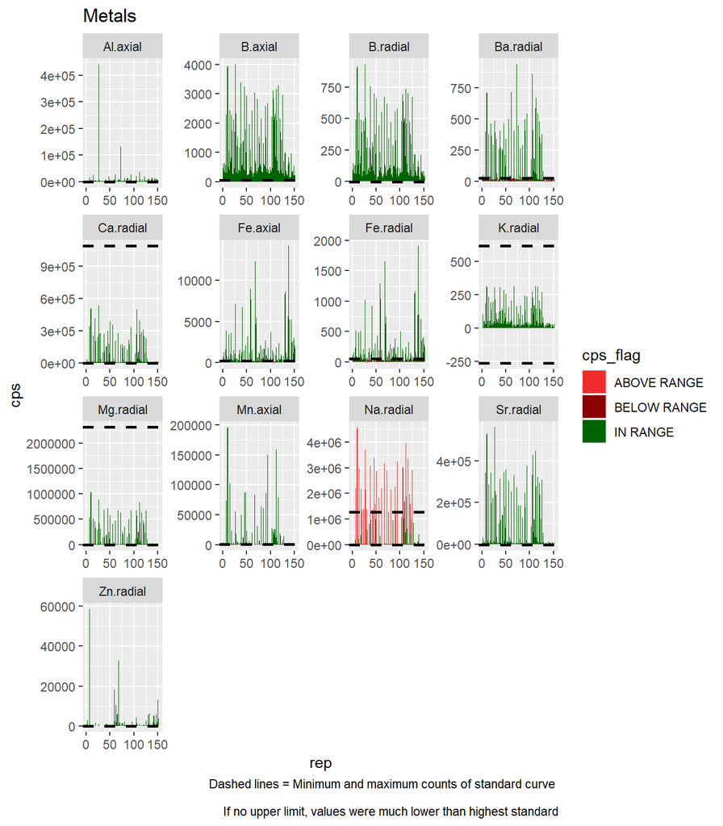

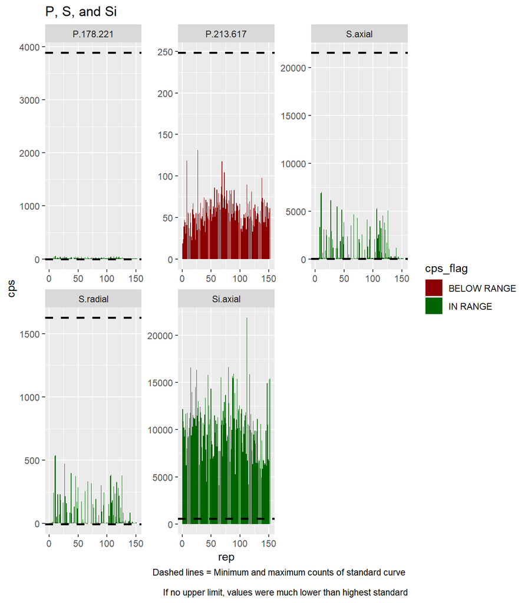

Red elements had <80% of samples within range of standard curve

| Element | Pass_percent | range_flag |
| --- | --- | --- |
| Al.axial | 100.0 | PASS |
| B.axial | 100.0 | PASS |
| B.radial | 100.0 | PASS |
| Ba.radial | 42.1 | FAIL |
| Ca.radial | 98.7 | PASS |
| Fe.axial | 82.9 | PASS |
| Fe.radial | 61.8 | FAIL |
| K.radial | 100.0 | PASS |
| Mg.radial | 100.0 | PASS |
| Mn.axial | 38.8 | FAIL |
| Na.radial | 77.0 | FAIL |
| P.178.221 | 99.3 | PASS |
| P.213.617 | 0.0 | FAIL |
| S.axial | 94.7 | PASS |
| S.radial | 97.4 | PASS |
| Si.axial | 100.0 | PASS |
| Sr.radial | 100.0 | PASS |
| Zn.radial | 97.4 | PASS |

**Samples with low Fe Concentrations**

| Percent_low | number_low | number_FW | number_SW | number_C |
| --- | --- | --- | --- | --- |
| 17.1 | 26 | 10 | 16 | 0 |

## Asses Metal Check Standards

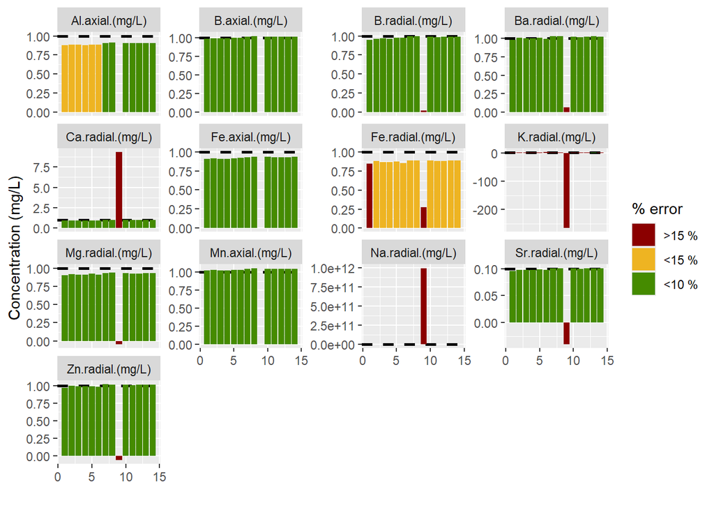

**LIST OF ELEMENTS WITH <80% OF CHECK STANDARDS WITHIN 15% OF EXPECTED CONCENTRATION - REASSESS**

| Element |
| --- |
| K.radial |

Replicate with weird value accross elements had very high internal standard; suspect there was not enough solution in vial

## Assess P, S, and Si Check Standards

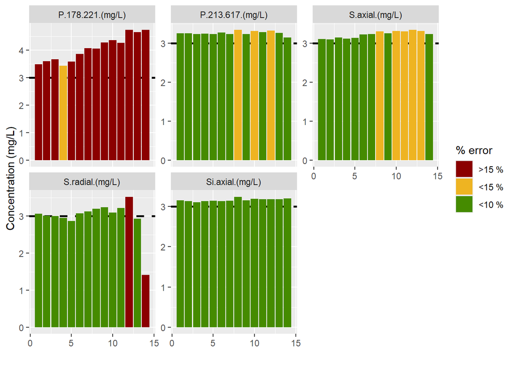

**LIST OF ELEMENTS WITH <80% OF CHECK STANDARDS WITHIN 15% OF EXPECTED CONCENTRATION - REASSESS**

| Element |
| --- |
| P.178.221 |

## Check Internal Standards

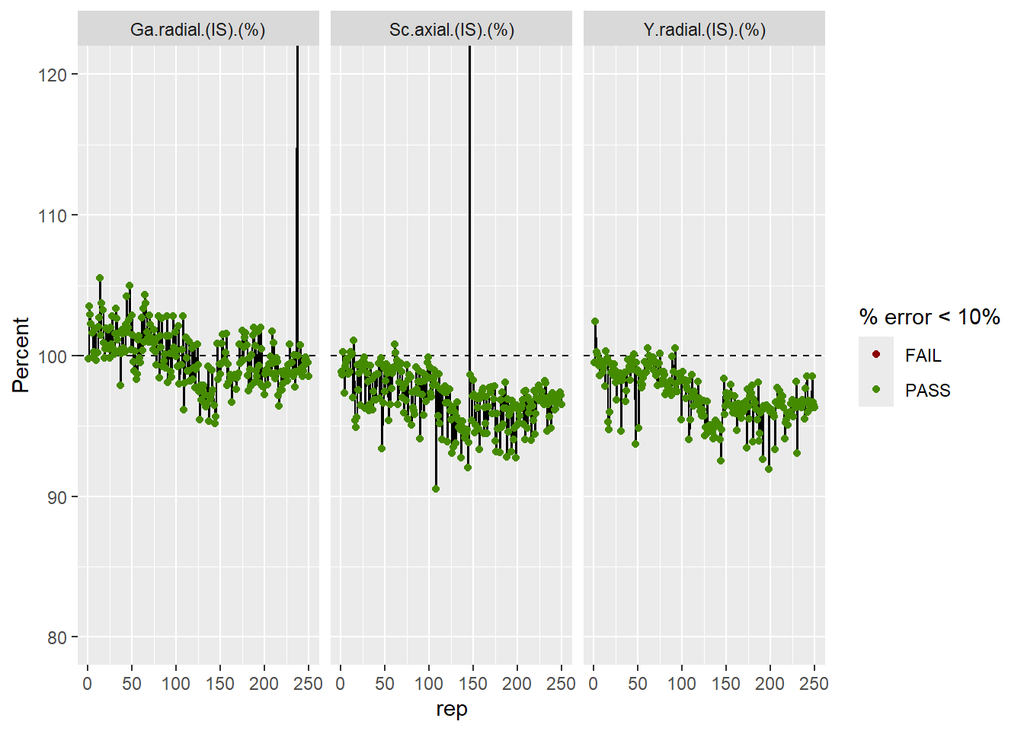

99.7322623828648 % of Internal Standards measurements are within 10% of 100

**Samples with low internal standard**[[1]] [1] “M 1” “P 3.0”

## Additional Checks

### NIST 1643f and Multi-elemental standard (QCS) are used as additional checks with a 10x dilution

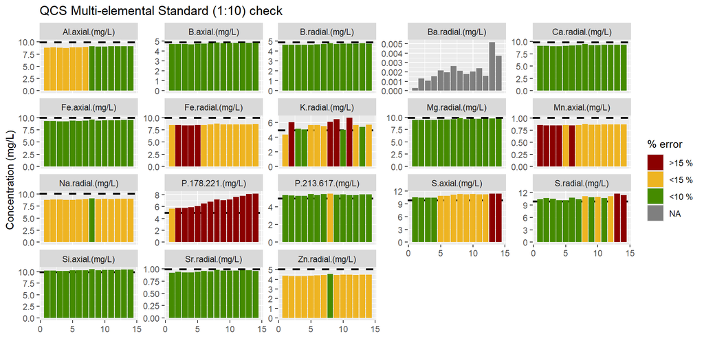

**LIST OF ELEMENTS WITH <80% OF CHECK STANDARDS WITHIN 15% OF EXPECTED CONCENTRATION - REASSESS**

| Element | Avg % Error |
| --- | --- |
| Fe.radial | 13.95 |
| K.radial | 14.47 |
| Mn.axial | 14.42 |
| P.178.221 | 38.09 |

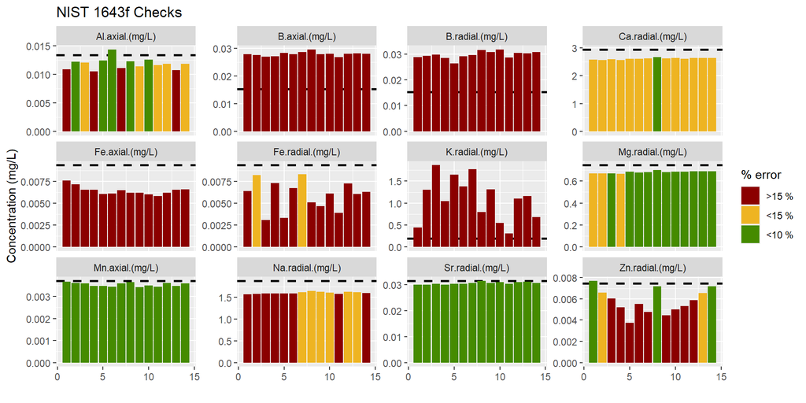

**LIST OF ELEMENTS WITH <80% OF NIST CHECKS WITHIN 15% OF EXPECTED CONCENTRATION - REASSESS**

| Element | Avg % Error |
| --- | --- |
| Al.axial | 12.62 |
| B.axial | 83.10 |
| B.radial | 94.93 |
| Fe.axial | 31.27 |
| Fe.radial | 36.78 |
| K.radial | 468.65 |
| Na.radial | 14.87 |
| Zn.radial | 22.61 |

### Duplicate samples

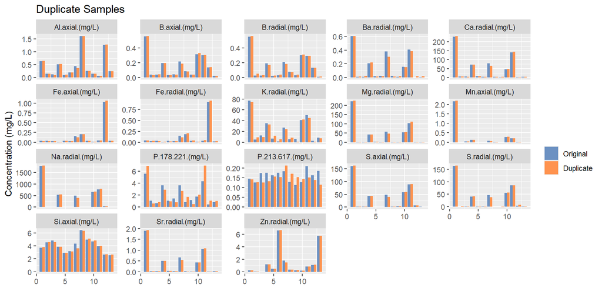

**LIST OF ELEMENTS WITH <80% OF DUPLICATE SAMPLES WITHIN 15% OF SAMPLE CONCENTRATION - REASSESS**

| Element | Avg % Difference |
| --- | --- |
| B.radial | 17.97 |
| Ba.radial | 43.92 |
| Fe.radial | 21.75 |
| K.radial | 43.33 |
| Mn.axial | 21.96 |
| P.178.221 | 41.39 |
| P.213.617 | 20.21 |
| S.radial | 133.43 |
| Zn.radial | 11.25 |

### Sample Spikes

*Samples spiked with 0.2 mL of LFB (M10)*

*Spiked samples with > DF 3.5 removed due to poor accuracy*

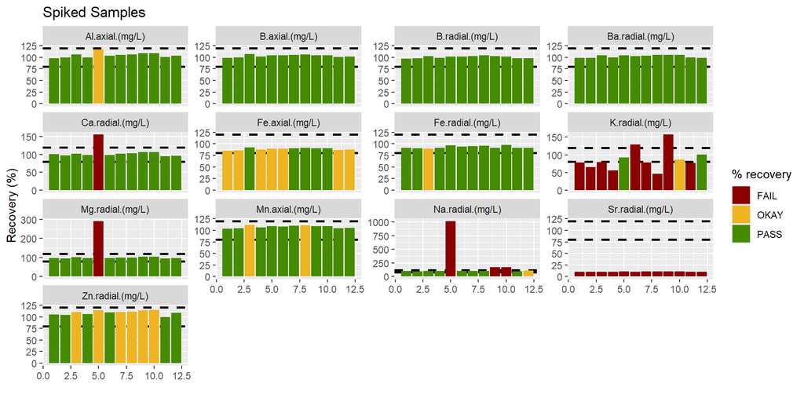

**LIST OF ELEMENTS WITH <80% OF SPIKED SAMPLES WITH 100 (+/- 20%) PERCENT RECOVERY - REASSESS**

| Element | Avg % Recovery |
| --- | --- |
| K.radial.(mg/L) | 86.93 |
| Na.radial.(mg/L) | 189.28 |
| Sr.radial.(mg/L) | 10.55 |

# **Summary of QA/QC Results**

*Red elements did not pass QA/QC Checks*

Red elements did not pass QA/QC checks

| Element | Number of Checks | Fail (%) | Passed_checks | Failed_checks | QAQC |
| --- | --- | --- | --- | --- | --- |
| Al.axial | 5 | 20 | range, chk , QCS , dup | NIST | PASS |
| B.axial | 5 | 20 | range, chk , QCS , dup | NIST | PASS |
| B.radial | 5 | 40 | range, chk , QCS | NIST, dup | PASS |
| Ba.radial | 3 | 67 | chk | range, dup | FAIL |
| Ca.radial | 5 | 0 | range, chk , NIST , QCS , dup |  | PASS |
| Fe.axial | 5 | 20 | range, chk , QCS , dup | NIST | PASS |
| Fe.radial | 5 | 80 | chk | range, NIST , QCS , dup | FAIL |
| K.radial | 5 | 80 | range | chk , NIST, QCS , dup | FAIL |
| Mg.radial | 5 | 0 | range, chk , NIST , QCS , dup |  | PASS |
| Mn.axial | 5 | 60 | chk , NIST | range, QCS , dup | PASS |
| Na.radial | 5 | 40 | chk, QCS, dup | range, NIST | PASS |
| P.178.221 | 4 | 75 | range | chk, QCS, dup | FAIL |
| P.213.617 | 4 | 50 | chk, QCS | range, dup | PASS |
| S.axial | 4 | 0 | range, chk , QCS , dup |  | PASS |
| S.radial | 4 | 25 | range, chk , QCS | dup | PASS |
| Si.axial | 4 | 0 | range, chk , QCS , dup |  | PASS |
| Sr.radial | 5 | 0 | range, chk , NIST , QCS , dup |  | PASS |
| Zn.radial | 5 | 40 | range, chk , QCS | NIST, dup | PASS |

# Sample Processing Steps

1. Sample concentrations were compared to blank concentrations. If sample concentration < blank concentration, then the sample concentration was set to zero.
2. Dilution factor was applied to each sample. In most cases, DF=5
3. Flags added to elments that had a poor standard curve.
4. Elements that did not pass QAQC were removed from the dataset
5. Removed samples that had low internal standards (<90%)
6. Column added to data listing elements that did not pass QAQC
7. Data exported to .csv

# Preliminary Plot of Data

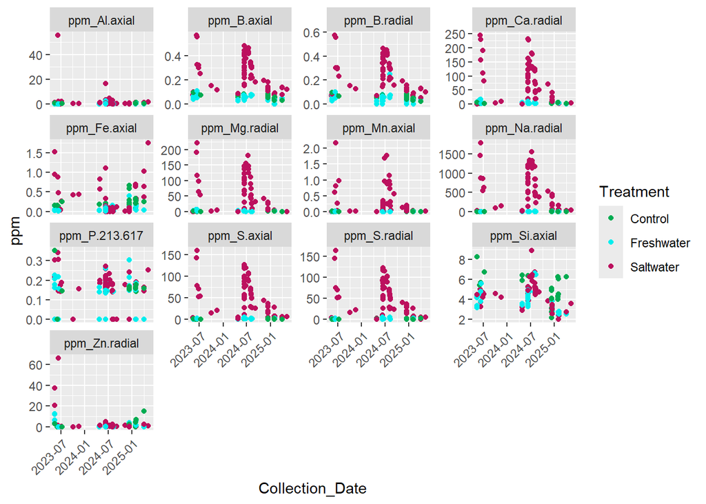